# Reproducible Research: Peer Assessment 1

## Loading and preprocessing the data

*Show any code that is needed to*

1. *Load the data (i.e. `read.csv()`)*
2. *Process/transform the data (if necessary) into a format suitable for your analysis*

The code is loaded with the following commands

```r
# move to the right directors
setwd("~/GitHub/Coursera/DataScience/ReproducibleResearch")

# read the data
data.raw <- read.csv("activity.csv")
```

**Answer:** All the data is stored in the variable `data.raw`.

**Preprocessing:** load libraries required for the analysis

```r
# libraries required
library(ggplot2, warn.conflicts = FALSE, quietly=TRUE)
library(dplyr, warn.conflicts = FALSE, quietly=TRUE)
library(data.table, warn.conflicts = FALSE, quietly=TRUE)
library(chron, warn.conflicts = FALSE, quietly=TRUE)
# option on how to represent numbers
options(scipen=999)
```

A quick inspection

```r
names(data.raw)
```

```
## [1] "steps"    "date"     "interval"
```

```r
str(data.raw)
```

```
## 'data.frame':    17568 obs. of  3 variables:
##  $ steps   : int  NA NA NA NA NA NA NA NA NA NA ...
##  $ date    : Factor w/ 61 levels "2012-10-01","2012-10-02",..: 1 1 1 1 1 1 1 1 1 1 ...
##  $ interval: int  0 5 10 15 20 25 30 35 40 45 ...
```

## What is mean total number of steps taken per day?

*For this part of the assignment, you can ignore the missing values in the dataset.*

1. *Make a histogram of the total number of steps taken each day*

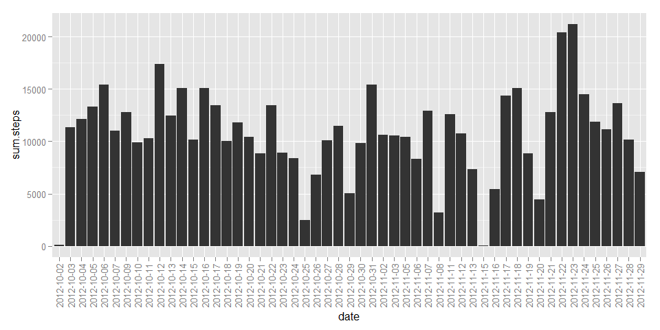

```r
# ignore the missing values
data.no_na <- na.omit(data.raw)

# extract the number of steps per day
data.sum.day_steps <- summarise(group_by(data.no_na, date),
                                sum.steps=sum(steps))
# plot it
qplot(date,sum.steps,data=data.sum.day_steps,
      geom="histogram",
      stat="identity")+
  # fix labels position
  theme(axis.text.x = element_text(angle = 90,
                                   vjust = 0.5, hjust=1))
```

2. *Calculate and report the **mean** and **median** total number of steps taken per day*

```r
# compute the mean
data.mean_day_steps <- mean(data.sum.day_steps$sum.steps)

# compute the median
data.median_day_steps <- median(data.sum.day_steps$sum.steps)
```

**Answer:**  
- the mean daily number of steps is 10766.1886792 - the median daily number of steps is 10765

### What is the average daily activity pattern?

1. *Make a time series plot (i.e. `type = "l"`) of the 5-minute interval (x-axis) and the average number of steps taken, averaged across all days (y-axis)*

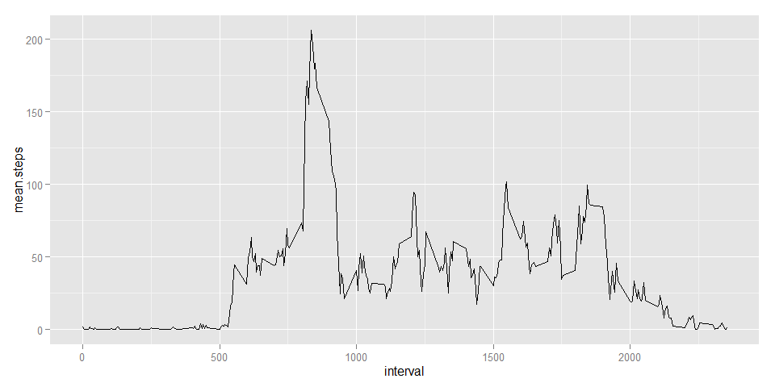

```r
# compute the average number of steps taken, averaged across all days
# based on the 5-minute interval
data.no_na.mean_interval_steps <- summarise(group_by(data.no_na,
                                                     interval),
                                            mean.steps= mean(steps))
# plot the the 5-minute interval (x-axis) and the average number of steps taken, averaged across all days (y-axis)

qplot(interval, mean.steps, data=data.no_na.mean_interval_steps,geom="line")
```

2. *Which 5-minute interval, on average across all the days in the dataset, contains the maximum number of steps?*

```r
# sort the  list
sort.mean.interval.steps <- arrange(data.no_na.mean_interval_steps,
                                    desc(mean.steps))
# extract the first one
sort.mean.interval.steps[1,]
```

```
## Source: local data frame [1 x 2]
##
##   interval mean.steps
## 1      835   206.1698
```

*Answer:* The 5-minute interval, on average across all the days in the dataset, that contains the maximum number of steps is 835 with 206.1698113 steps.

### Inputing missing values

*Note that there are a number of days/intervals where there are missing values (coded as `NA`). The presence of missing days may introduce bias into some calculations or summaries of the data.*

1. *Calculate and report the total number of missing values in the dataset (i.e. the total number of rows with `NA`s)*

```r
# calculate the number of missing values
dimNA <- dim(data.raw) - dim(data.no_na)
# report the value
dimNA[1]
```

```
## [1] 2304
```

**Answer:** The number of total ‘NA’ is 2304

2. *Devise a strategy for filling in all of the missing values in the dataset. The strategy does not need to be sophisticated. For example, you could use the mean/median for that day, or the mean for that 5-minute interval, etc.*

I address the question by replacing the missing values with the mean value of the same interval across all days

```r
# transform the data frame in a data table for easy indexing
data.no_na.mean_interval_steps <- data.table(data.no_na.mean_interval_steps)

# this function replaces the NAs with the estimates
# if the steps is NA, replace it the instant mean
# otherwise keep the value
na.fill <- function (steps,intervals) {
  # check whether the value of steps is NA
  ifelse (is.na(steps),
          # >if case < retrieve the mean value of steps at that interval
          data.no_na.mean_interval_steps[interval==intervals,mean.steps],
          # > else case< simply use the current steps value
          steps)
}
```

**Answer:** The strategy adopted replaces NAs with the corresponding instance averaged across all days using the function `na.fill` defined above.

3. *Create a new dataset that is equal to the original dataset but with the missing data filled in.*

```r
# apply the function to the raw data read from the file
data.estimated <- transform(data.raw,steps=na.fill(steps,interval))
```

**Answer:** The data with the estimates is stored in `data.estimated`.

4. *Make a histogram of the total number of steps taken each day*
- *Calculate and report the **mean** and **median** total number of steps taken per day.*
- *Do these values differ from the estimates from the first part of the assignment?*
- *What is the impact of imputing missing data on the estimates of the total daily number of steps?*

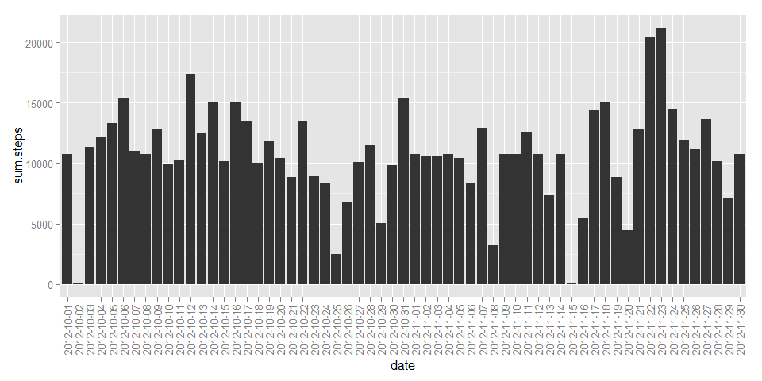

```r
# extract the number of steps per day
data.estimated.sum.day_steps <- summarise(group_by(data.estimated, date),
                                        sum.steps=sum(steps))
# plot it
qplot(date,sum.steps,data=data.estimated.sum.day_steps,
      geom="histogram",
      stat="identity")+
  # fix labels position
  theme(axis.text.x = element_text(angle = 90,
                                   vjust = 0.5, hjust=1))
```

```r
# compute the mean
data.estimated.mean_day_steps <- mean(data.estimated.sum.day_steps$sum.steps)

# compute the median
data.estimated.median_day_steps <- median(data.estimated.sum.day_steps$sum.steps)
```

**Answer:**  
- *Calculate and report the **mean** and **median** total number of steps taken per day.*

The mean daily number of steps using the estimated data is 10766.1886792 while the median is 10766.1886792.

- *Do these values differ from the estimates from the first part of the assignment?*

`data.estimated.mean_day_steps - data.mean_day_steps` = 0

and

`data.estimated.median_day_steps - data.median_day_steps` = 1.1886792

### Are there differences in activity patterns between weekdays and weekends?

*For this part the `weekdays()` function may be of some help here. Use the dataset with the filled-in missing values for this part.*

1. *Create a new factor variable in the dataset with two levels – “weekday” and “weekend” indicating whether a given date is a weekday or weekend day.*

```r
# define constant labels for week end and week
weekend.level <- "weekend"
weekday.level <- "weekday"

# distinguish week ends from week days.
data.estimated.we_wd <- mutate(data.estimated,
                               we_wd=ifelse(is.weekend(as.Date(date)),
                                            weekend.level,
                                            weekday.level))
# transform the we_wd variable in a factor
# (strickly speakinng it is not needed, but it seems to be required by the homework)
data.estimated.we_wd$we_wd <- as.factor(data.estimated.we_wd$we_wd)
```

**Answer:** `data.estimated.we_wd` is a table which contains the same content of data.estimated`, but it also contains a variables with the two factors

2. *Make a panel plot containing a time series plot (i.e. `type = "l"`) of the 5-minute interval (x-axis) and the average number of steps taken, averaged across all weekday days or weekend days (y-axis). The plot should look something like the following, which was created using **simulated data**:*

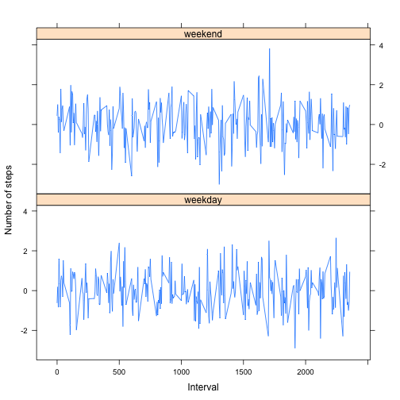

**Your plot will look different from the one above** *because you will be using the activity monitor data. Note that the above plot was made using the lattice system but you can make the same version of the plot using any plotting system you choose.*

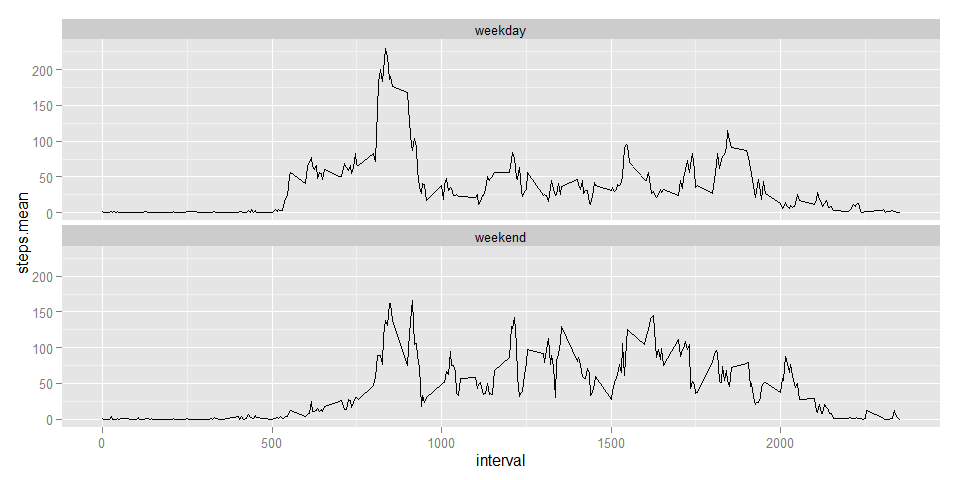

```r
# compute the mean steps distinguishing week days and week ends
mean.interval.steps <- summarise(group_by(data.estimated.we_wd,
                                          interval,
                                          we_wd),
                                 steps.mean = mean(steps))

# make two plots

plot.final <- ggplot(mean.interval.steps,aes(interval,steps.mean))+
  #using line geometry as required
  geom_line()+
  # faceting on weekend/weekday
  facet_wrap(~we_wd,ncol=1)

# plot the graph
plot.final
```